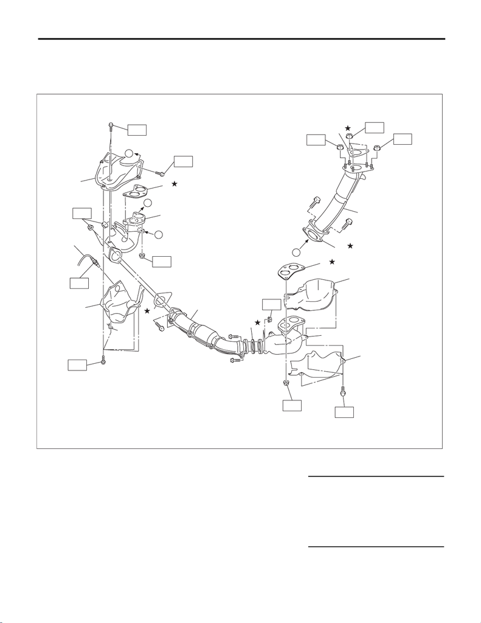

General Description

EXHAUST

1. General Description

A: COMPONENT

1. FRONT EXHAUST PIPE

(1) Gasket (8) Exhaust manifold LH inner cover (15) Ground cable

(2) Exhaust manifold RH upper cover (9) Exhaust manifold LH outer cover

(3) Exhaust manifold RH (10) Gasket Tightening torque: N·m (kgf-m, ft-lb)

(4) Exhaust manifold RH lower cover (11) Joint pipe T1: 19 (1.9, 14.0)

(5) Gasket (12) Gasket T2: 40 (4.1, 29.5)

(6) Front exhaust pipe (13) Front oxygen (A/F) sensor T3: 42.5 (4.3, 31.3)

TION, Front Oxygen (A/F) Sen-

sor.>

EX-02726

T1

T3

T3

T2

T1

T1

(3)

(1)

(9)

(8)

(6)

(11)

(12)

(14)

(10)

(4)

(2)

(13)

T4

(5)

(7)

(15)

T3

T3

T3

A

B

B

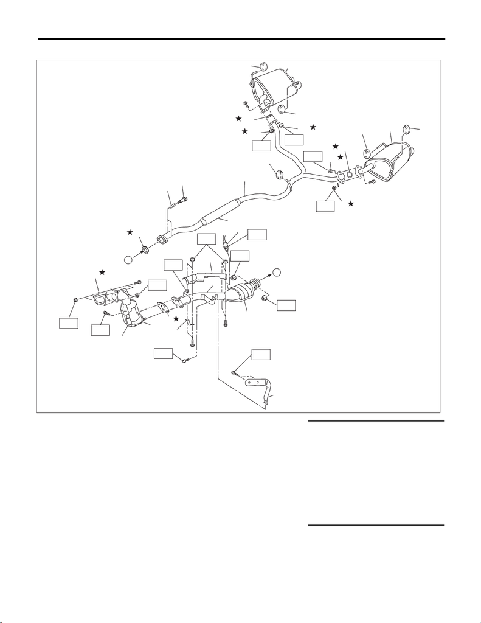

General Description

EXHAUST

2. CENTER AND REAR EXHAUST PIPE, AND MUFFLER

(1) Gasket (12) Chamber Tightening torque: N·m (kgf-m, ft-lb)

(2) Front catalytic converter (13) Cushion rubber T1: 13 (1.3, 9.6)

(3) Center exhaust pipe (front) (14) Spring T2: 18 (1.8, 13.3)

(4) Center exhaust pipe (rear) (15) Bolt T3: 30 (3.1, 22.1)

(5) Gasket (16) Gasket T4: 35 (3.6, 25.8)

(6) Center exhaust pipe upper cover (17) Self-locking nut T5: 40 (4.1, 29.5)

(7) Clamp (18) Muffler LH T6: 42.5 (4.3, 31.3)

(8) Rear oxygen sensor (19) Muffler RH T7: 48 (4.9, 35.4)

(9) Rear catalytic converter (20) Hanger bracket T8: <Ref. to FU(STI)-54, INSTALLA-

TION, Rear Oxygen Sensor.>

(10) Gasket

(11) Rear exhaust pipe

(10)

(11)

(12)

(15)

(14)

(13)

(13)

(16)

(13)

(16)

(18)

(19)

(13)

(13)

(17)

(17)

(17)

T7

T7

T7

(9)

T4

T6

T2

(6)

(4)

(8)

(7)

T2

T1

T8

(5)

T3

T6

T6

(1)

(2)

(3)

A

T5

(20)

EX-03166

[figure not shown]

General Description

EXHAUST

B: CAUTION

• Prior to starting work, pay special attention to the following:

1. Always wear work clothes, a work cap, and protective shoes. Additionally, wear a helmet, protective

goggles, etc. if necessary.

2. Protect the vehicle using a seat cover, fender cover, etc.

3. Prepare the service tools, clean cloth, containers to catch grease and oil, etc.

• Vehicle components are extremely hot immediately after driving. Be wary of receiving burns from heated

parts.

• When performing a repair, identify the cause of trouble and avoid unnecessary removal, disassembly and

replacement.

• Before disconnecting connectors of sensors or units, be sure to disconnect the ground cable from battery.

• Always use the jack-up point when the shop jacks or rigid racks are used to support the vehicle.

• Remove contamination including dirt and corrosion before removal, installation, disassembly or assembly.

• Keep the removed parts in order and protect them from dust and dirt.

• All removed parts, if to be reused, should be reinstalled in the original positions with attention to the correct

directions, etc.

• Bolts, nuts and washers should be replaced with new parts as required.

• Be sure to tighten the fasteners including bolts and nuts to the specified torque.

• If any grease adheres to the exhaust pipe, wipe it off. Otherwise a fire may happen.